# Assignment_2

Joseph Demore

2026-10-04

### Small tidbits about my style;

```
=== logically equivalent to;
== is equal to
{ } usaully used to point to a variable name or choice that varies from directions
        (i try to make my life easier from a coding side)
```

```r
# short block to check if the packages are installed; will download and install any that are not.
packages <- c("class", "caret", "gmodels")

for (pkg in packages) {
  if (!requireNamespace(pkg, quietly = TRUE)) install.packages(pkg, repos = "https://cloud.r-project.org")
  library(pkg, character.only = TRUE)
}
```

### Helpers / things I reused.

```r
# helper fn's

# fn to count unique
uCount <- function(x) {
  length(unique(x))
}

# normalizations for data
normalize <- function(data, model) {
  data[qVars] <- predict(model, data[qVars])
  data[predictors]
}

# accuracy fn for knn
knnAcc <- function(k, trainX, testX, trainY, testY) {
  mean(knn(trainX, testX, cl = trainY, k = k) == testY)
}

# cross table helper
knnCross <- function(k, trainX, testX, trainY, testY) {
  CrossTable(testY, knn(trainX, testX, cl = trainY, k = k), prop.chisq = FALSE)
}

# summary for the knn { used with end/knnCross comparison }
knnSummary <- function(k, trainX, testX, trainY, testY) {
  cm <- table(factor(testY, levels = c("0", "1")),
              factor(knn(trainX, testX, cl = trainY, k = k), levels = c("0", "1")))
  TN <- cm[1, 1]; FP <- cm[1, 2]; FN <- cm[2, 1]; TP <- cm[2, 2]
  data.frame(n = sum(cm), TN, FP, FN, TP,
             Accuracy = (TP + TN) / sum(cm),
             Sensitivity = TP / (TP + FN),
             Specificity = TN / (TN + FP),
             Precision = TP / (TP + FP))
}
```

### Data Setup & Inspection

Sorted Ascending by unique values to help id cat’s. not dogs. cats.

```r
# Reads UniversalBank.csv; str shows structure (colnam, type, 10 values)
uBank <- read.csv("UniversalBank.csv")
str(uBank)
```

```
## 'data.frame':    5000 obs. of  14 variables:
##  $ ID                : int  1 2 3 4 5 6 7 8 9 10 ...
##  $ Age               : int  25 45 39 35 35 37 53 50 35 34 ...
##  $ Experience        : int  1 19 15 9 8 13 27 24 10 9 ...
##  $ Income            : int  49 34 11 100 45 29 72 22 81 180 ...
##  $ ZIP.Code          : int  91107 90089 94720 94112 91330 92121 91711 93943 90089 93023 ...
##  $ Family            : int  4 3 1 1 4 4 2 1 3 1 ...
##  $ CCAvg             : num  1.6 1.5 1 2.7 1 0.4 1.5 0.3 0.6 8.9 ...
##  $ Education         : int  1 1 1 2 2 2 2 3 2 3 ...
##  $ Mortgage          : int  0 0 0 0 0 155 0 0 104 0 ...
##  $ Personal.Loan     : int  0 0 0 0 0 0 0 0 0 1 ...
##  $ Securities.Account: int  1 1 0 0 0 0 0 0 0 0 ...
##  $ CD.Account        : int  0 0 0 0 0 0 0 0 0 0 ...
##  $ Online            : int  0 0 0 0 0 1 1 0 1 0 ...
##  $ CreditCard        : int  0 0 0 0 1 0 0 1 0 0 ...
```

```r
# summary to check data
summary(uBank)
```

```
##        ID            Age          Experience       Income          ZIP.Code
##  Min.   :   1   Min.   :23.00   Min.   :-3.0   Min.   :  8.00   Min.   : 9307
##  1st Qu.:1251   1st Qu.:35.00   1st Qu.:10.0   1st Qu.: 39.00   1st Qu.:91911
##  Median :2500   Median :45.00   Median :20.0   Median : 64.00   Median :93437
##  Mean   :2500   Mean   :45.34   Mean   :20.1   Mean   : 73.77   Mean   :93153
##  3rd Qu.:3750   3rd Qu.:55.00   3rd Qu.:30.0   3rd Qu.: 98.00   3rd Qu.:94608
##  Max.   :5000   Max.   :67.00   Max.   :43.0   Max.   :224.00   Max.   :96651
##      Family          CCAvg          Education        Mortgage
##  Min.   :1.000   Min.   : 0.000   Min.   :1.000   Min.   :  0.0
##  1st Qu.:1.000   1st Qu.: 0.700   1st Qu.:1.000   1st Qu.:  0.0
##  Median :2.000   Median : 1.500   Median :2.000   Median :  0.0
##  Mean   :2.396   Mean   : 1.938   Mean   :1.881   Mean   : 56.5
##  3rd Qu.:3.000   3rd Qu.: 2.500   3rd Qu.:3.000   3rd Qu.:101.0
##  Max.   :4.000   Max.   :10.000   Max.   :3.000   Max.   :635.0
##  Personal.Loan   Securities.Account   CD.Account         Online
##  Min.   :0.000   Min.   :0.0000     Min.   :0.0000   Min.   :0.0000
##  1st Qu.:0.000   1st Qu.:0.0000     1st Qu.:0.0000   1st Qu.:0.0000
##  Median :0.000   Median :0.0000     Median :0.0000   Median :1.0000
##  Mean   :0.096   Mean   :0.1044     Mean   :0.0604   Mean   :0.5968
##  3rd Qu.:0.000   3rd Qu.:0.0000     3rd Qu.:0.0000   3rd Qu.:1.0000
##  Max.   :1.000   Max.   :1.0000     Max.   :1.0000   Max.   :1.0000
##    CreditCard
##  Min.   :0.000
##  1st Qu.:0.000
##  Median :0.000
##  Mean   :0.294
##  3rd Qu.:1.000
##  Max.   :1.000
```

```r
# uCount on each col to help identify categoricals
sapply(uBank, uCount)
```

```
##                 ID                Age         Experience             Income
##               5000                 45                 47                162
##           ZIP.Code             Family              CCAvg          Education
##                467                  4                108                  3
##           Mortgage      Personal.Loan Securities.Account         CD.Account
##                347                  2                  2                  2
##             Online         CreditCard
##                  2                  2
```

```r
# sorted
sort(sapply(uBank, uCount))
```

```
##      Personal.Loan Securities.Account         CD.Account             Online
##                  2                  2                  2                  2
##         CreditCard          Education             Family                Age
##                  2                  3                  4                 45
##         Experience              CCAvg             Income           Mortgage
##                 47                108                162                347
##           ZIP.Code                 ID
##                467               5000
```

```r
# categoricals:
# Personal.Loan [target outcome], Securities.Account, CD.Account, Online,
# CreditCard, Education [this needs to be split]
# Zip Code and ID (arith not going to do anything here) but we're dropping

# Numeric:
# Family (even though count is small), Age, Experience, CCAvg, Income, Mortgage
```

### Bad data || but instructions say to keep all predictors except-listed.

```r
# summary showed -3 experience value;... assuming this is correlated to -3 years
# it's likely bad data -- these rows //should// be removed.
# especially since all - experience customers declined the loan.
summary(uBank$Experience)
```

```
##    Min. 1st Qu.  Median    Mean 3rd Qu.    Max.
##    -3.0    10.0    20.0    20.1    30.0    43.0
```

```r
head(sort(uBank$Experience))
```

```
## [1] -3 -3 -3 -3 -2 -2
```

```r
head(uBank[uBank$Experience < 0, ])
```

```
##      ID Age Experience Income ZIP.Code Family CCAvg Education Mortgage
## 90   90  25         -1    113    94303      4  2.30         3        0
## 227 227  24         -1     39    94085      2  1.70         2        0
## 316 316  24         -2     51    90630      3  0.30         3        0
## 452 452  28         -2     48    94132      2  1.75         3       89
## 525 525  24         -1     75    93014      4  0.20         1        0
## 537 537  25         -1     43    92173      3  2.40         2      176
##     Personal.Loan Securities.Account CD.Account Online CreditCard
## 90              0                  0          0      0          1
## 227             0                  0          0      0          0
## 316             0                  0          0      1          0
## 452             0                  0          0      1          0
## 525             0                  0          0      1          0
## 537             0                  0          0      1          0
```

```r
nrow(uBank[uBank$Experience < 0, c("Experience", "Personal.Loan")])
```

```
## [1] 52
```

```r
# verify they're all negative. true == all declined.
# this is === if ALL people with negative experience are declined, print true
all(uBank$Personal.Loan[uBank$Experience<0] == 0)
```

```
## [1] TRUE
```

### Customer definition from the assignment (for q1, q4)

```r
sCust <- data.frame(
  Age = 40,
  Experience = 10,
  Income = 84,
  Family = 2,
  CCAvg = 2,
  Education_1 = 0,
  Education_2 = 1,
  Education_3 = 0,
  Mortgage = 0,
  Securities.Account = 0,
  CD.Account = 0,
  Online = 1,
  CreditCard = 1
)
```

### Sample has Edu1,Edu2, Edu3 so we can factor edu

Set diff shows id / zip / edu / pers loan as differences once edu is factored we will remove id, zip, personal loan (though i would have assumed zip would be relevant, location matters). It would have been cool to geoplot them on a heatmap.

```r
setdiff(names(uBank), names(sCust))
```

```
## [1] "ID"            "ZIP.Code"      "Education"     "Personal.Loan"
```

### Drop ID, Zip then split nonbinary categoricals

```r
# categorizes education via factor, binds to df and removes dropped cols
# note sep by _ is only there to match the sample customer.
uBank$Education <- factor(uBank$Education)
uBank <- cbind(uBank, predict(dummyVars(~ Education, data = uBank, sep = "_"), uBank))
uBank$Education <- NULL
uBank$ID <- NULL
uBank$ZIP.Code <- NULL

summary(uBank)
```

```
##       Age          Experience       Income           Family
##  Min.   :23.00   Min.   :-3.0   Min.   :  8.00   Min.   :1.000
##  1st Qu.:35.00   1st Qu.:10.0   1st Qu.: 39.00   1st Qu.:1.000
##  Median :45.00   Median :20.0   Median : 64.00   Median :2.000
##  Mean   :45.34   Mean   :20.1   Mean   : 73.77   Mean   :2.396
##  3rd Qu.:55.00   3rd Qu.:30.0   3rd Qu.: 98.00   3rd Qu.:3.000
##  Max.   :67.00   Max.   :43.0   Max.   :224.00   Max.   :4.000
##      CCAvg           Mortgage     Personal.Loan   Securities.Account
##  Min.   : 0.000   Min.   :  0.0   Min.   :0.000   Min.   :0.0000
##  1st Qu.: 0.700   1st Qu.:  0.0   1st Qu.:0.000   1st Qu.:0.0000
##  Median : 1.500   Median :  0.0   Median :0.000   Median :0.0000
##  Mean   : 1.938   Mean   : 56.5   Mean   :0.096   Mean   :0.1044
##  3rd Qu.: 2.500   3rd Qu.:101.0   3rd Qu.:0.000   3rd Qu.:0.0000
##  Max.   :10.000   Max.   :635.0   Max.   :1.000   Max.   :1.0000
##    CD.Account         Online         CreditCard     Education_1
##  Min.   :0.0000   Min.   :0.0000   Min.   :0.000   Min.   :0.0000
##  1st Qu.:0.0000   1st Qu.:0.0000   1st Qu.:0.000   1st Qu.:0.0000
##  Median :0.0000   Median :1.0000   Median :0.000   Median :0.0000
##  Mean   :0.0604   Mean   :0.5968   Mean   :0.294   Mean   :0.4192
##  3rd Qu.:0.0000   3rd Qu.:1.0000   3rd Qu.:1.000   3rd Qu.:1.0000
##  Max.   :1.0000   Max.   :1.0000   Max.   :1.000   Max.   :1.0000
##   Education_2      Education_3
##  Min.   :0.0000   Min.   :0.0000
##  1st Qu.:0.0000   1st Qu.:0.0000
##  Median :0.0000   Median :0.0000
##  Mean   :0.2806   Mean   :0.3002
##  3rd Qu.:1.0000   3rd Qu.:1.0000
##  Max.   :1.0000   Max.   :1.0000
```

```r
# only remaining Personal.Loan (acceptance) is missing from the sample customer.
setdiff(names(uBank), names(sCust))
```

```
## [1] "Personal.Loan"
```

### Let’s do some ML.. finally.

```r
# this one needs to be categorical since it's our target. other cat binarys need
# to stay 0-1 for euclid distance on knn.
uBank$Personal.Loan <- factor(uBank$Personal.Loan)

# make our randomness not randomness at all.
set.seed(1234567890)
# partition for t&v
split = createDataPartition(uBank$Personal.Loan, p=0.6, list = FALSE)
# training gets 60% and validation 40% // split indexes at 60% of data
training <- uBank[split,]
validation <- uBank[-split,]
# define predictors; which are all cols except personal loan //via setdiff
predictors <- setdiff(names(uBank), "Personal.Loan")
# define quant & cat: setdiff predictors&qVars to get cats. === (1- X) for names
qVars <- c("Age", "Experience", "Income", "Family", "CCAvg", "Mortgage")
cVars <- setdiff(predictors, qVars)
```

### Normalization…

Note I defined this above myself.

```r
# normalization of model, training, validation, and sample customer
normModel <- preProcess(training[qVars])
tNorm <- normalize(training, normModel)
vNorm <- normalize(validation, normModel)
cNorm <- normalize(sCust, normModel)
```

# **Question 1** k-NN for sCust

Success as 1 (loan accept) && cutoff 0.5. – with this one; cutoff is irrelevant since nearest neighbor will be 0 or 1

```r
knn(tNorm, cNorm, cl = training$Personal.Loan, k=1)
```

```
## [1] 0
## Levels: 0 1
```

### Classified as not accepted [Level 0].

# **Question 2** Choice of k that balances over-fitting&ignorance

```r
# odds here >> evens produce ties between yes-no
kTest <- seq(1, 49, by = 2)
acc <- sapply(kTest, knnAcc, tNorm, vNorm, training$Personal.Loan, validation$Personal.Loan)
acc
```

```
##  [1] 0.9585 0.9550 0.9575 0.9535 0.9515 0.9490 0.9480 0.9465 0.9460 0.9410
## [11] 0.9420 0.9410 0.9405 0.9380 0.9380 0.9335 0.9335 0.9315 0.9305 0.9280
## [21] 0.9270 0.9265 0.9260 0.9260 0.9265
```

```r
# exclude k==1 since it would just mimic its closest neighbor & that's
# the definition of overfitting.
begone <- kTest == 1
choice <- kTest[!begone][which.max(acc[!begone])]
choice
```

```
## [1] 5
```

```r
max(acc[!begone])
```

```
## [1] 0.9575
```

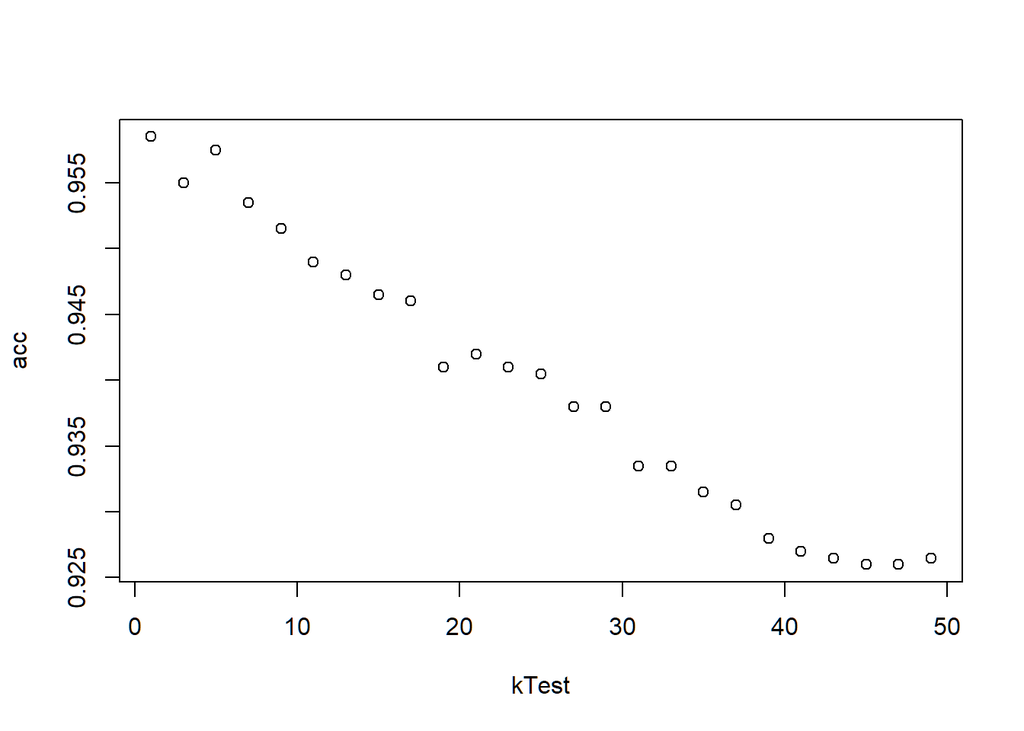

```r
plot(kTest, acc)
```

### I would choose k==5 for this, as it has the highest accuracy for k != 1.

Plot for great justice. Trend shows consistent downward tendency. k==49, the accuracy falls to ~92.6%, which is pretty close to the naive baseline. Larger K would ignore the predictors here.

# **Question 3** Confusion Matrix for validation on best k { choice } var

Cross table shows Acc 95.7%(1806+108 TN,TP/Total), but missed more than 40% of acceptance {sens==56%}. Still concerned about the negative experience data rows in our sample.

```r
# Cross table {def above}
knnCross(choice, tNorm, vNorm, training$Personal.Loan, validation$Personal.Loan)
```

```
##
##
##    Cell Contents
## |-------------------------|
## |                       N |
## |           N / Row Total |
## |           N / Col Total |
## |         N / Table Total |
## |-------------------------|
##
##
## Total Observations in Table:  2000
##
##
##              | knn(trainX, testX, cl = trainY, k = k)
##        testY |         0 |         1 | Row Total |
## -------------|-----------|-----------|-----------|
##            0 |      1806 |         2 |      1808 |
##              |     0.999 |     0.001 |     0.904 |
##              |     0.956 |     0.018 |           |
##              |     0.903 |     0.001 |           |
## -------------|-----------|-----------|-----------|
##            1 |        84 |       108 |       192 |
##              |     0.438 |     0.562 |     0.096 |
##              |     0.044 |     0.982 |           |
##              |     0.042 |     0.054 |           |
## -------------|-----------|-----------|-----------|
## Column Total |      1890 |       110 |      2000 |
##              |     0.945 |     0.055 |           |
## -------------|-----------|-----------|-----------|
##
##
```

```r
# summary fn ^^above used here
q3Summary <- rbind(
  Validation = knnSummary(choice, tNorm, vNorm, training$Personal.Loan, validation$Personal.Loan)
)
round(q3Summary, 4)
```

```
##               n   TN FP FN  TP Accuracy Sensitivity Specificity Precision
## Validation 2000 1806  2 83 109   0.9575      0.5677      0.9989     0.982
```

# **Question 4** Classify sCust with best k { choice } of 5

```r
knn(tNorm, cNorm, cl = training$Personal.Loan, k = choice)
```

```
## [1] 0
## Levels: 0 1
```

### Customer still gets rejected. He’s having a bad day, we re-ran his credit.

# **Question 5** Repartition; training->validation->test. k-NN with 5 && cMatr

so.. do it all again.

```r
# Three way split 50/30/20 // train first, then split the leftover
# reset seed so this split lands the same every run
set.seed(1234567890)

# training gets 50% (2500 rows)
q5Split <- createDataPartition(uBank$Personal.Loan, p = 0.5, list = FALSE)
q5Training <- uBank[q5Split, ]
# the other 50% is leftover (2500 rows)
q5Rest <- uBank[-q5Split, ]

# .6 of the leftover is validation (1500 = 30% of total); remaining is test (1000 = 20%)
q5RestSplit <- createDataPartition(q5Rest$Personal.Loan, p = 0.6, list = FALSE)
q5Validation <- q5Rest[q5RestSplit, ]
q5Test <- q5Rest[-q5RestSplit, ]

# normalize: fit on q5 training only, apply to all three
q5NormModel <- preProcess(q5Training[qVars])
q5tNorm <- normalize(q5Training, q5NormModel)
q5vNorm <- normalize(q5Validation, q5NormModel)
q5teNorm <- normalize(q5Test, q5NormModel)

# confusion matrices at best k { choice }: training on itself, then validation, then test
knnCross(choice, q5tNorm, q5tNorm, q5Training$Personal.Loan, q5Training$Personal.Loan)
```

```
##
##
##    Cell Contents
## |-------------------------|
## |                       N |
## |           N / Row Total |
## |           N / Col Total |
## |         N / Table Total |
## |-------------------------|
##
##
## Total Observations in Table:  2500
##
##
##              | knn(trainX, testX, cl = trainY, k = k)
##        testY |         0 |         1 | Row Total |
## -------------|-----------|-----------|-----------|
##            0 |      2260 |         0 |      2260 |
##              |     1.000 |     0.000 |     0.904 |
##              |     0.973 |     0.000 |           |
##              |     0.904 |     0.000 |           |
## -------------|-----------|-----------|-----------|
##            1 |        63 |       177 |       240 |
##              |     0.263 |     0.738 |     0.096 |
##              |     0.027 |     1.000 |           |
##              |     0.025 |     0.071 |           |
## -------------|-----------|-----------|-----------|
## Column Total |      2323 |       177 |      2500 |
##              |     0.929 |     0.071 |           |
## -------------|-----------|-----------|-----------|
##
##
```

```r
knnCross(choice, q5tNorm, q5vNorm, q5Training$Personal.Loan, q5Validation$Personal.Loan)
```

```
##
##
##    Cell Contents
## |-------------------------|
## |                       N |
## |           N / Row Total |
## |           N / Col Total |
## |         N / Table Total |
## |-------------------------|
##
##
## Total Observations in Table:  1500
##
##
##              | knn(trainX, testX, cl = trainY, k = k)
##        testY |         0 |         1 | Row Total |
## -------------|-----------|-----------|-----------|
##            0 |      1355 |         1 |      1356 |
##              |     0.999 |     0.001 |     0.904 |
##              |     0.959 |     0.011 |           |
##              |     0.903 |     0.001 |           |
## -------------|-----------|-----------|-----------|
##            1 |        58 |        86 |       144 |
##              |     0.403 |     0.597 |     0.096 |
##              |     0.041 |     0.989 |           |
##              |     0.039 |     0.057 |           |
## -------------|-----------|-----------|-----------|
## Column Total |      1413 |        87 |      1500 |
##              |     0.942 |     0.058 |           |
## -------------|-----------|-----------|-----------|
##
##
```

```r
knnCross(choice, q5tNorm, q5teNorm, q5Training$Personal.Loan, q5Test$Personal.Loan)
```

```
##
##
##    Cell Contents
## |-------------------------|
## |                       N |
## |           N / Row Total |
## |           N / Col Total |
## |         N / Table Total |
## |-------------------------|
##
##
## Total Observations in Table:  1000
##
##
##              | knn(trainX, testX, cl = trainY, k = k)
##        testY |         0 |         1 | Row Total |
## -------------|-----------|-----------|-----------|
##            0 |       903 |         1 |       904 |
##              |     0.999 |     0.001 |     0.904 |
##              |     0.960 |     0.017 |           |
##              |     0.903 |     0.001 |           |
## -------------|-----------|-----------|-----------|
##            1 |        38 |        58 |        96 |
##              |     0.396 |     0.604 |     0.096 |
##              |     0.040 |     0.983 |           |
##              |     0.038 |     0.058 |           |
## -------------|-----------|-----------|-----------|
## Column Total |       941 |        59 |      1000 |
##              |     0.941 |     0.059 |           |
## -------------|-----------|-----------|-----------|
##
##
```

```r
# summary table { built from fn ^^ above / near top }
# training on itself, then validation, then test
# -- based on metrics in slides. recall===sensitivity
q5Summary <- rbind(
  Training = knnSummary(choice, q5tNorm, q5tNorm, q5Training$Personal.Loan, q5Training$Personal.Loan),
  Validation = knnSummary(choice, q5tNorm, q5vNorm, q5Training$Personal.Loan, q5Validation$Personal.Loan),
  Test = knnSummary(choice, q5tNorm, q5teNorm, q5Training$Personal.Loan, q5Test$Personal.Loan)
)
round(q5Summary, 4)
```

```
##               n   TN FP FN  TP Accuracy Sensitivity Specificity Precision
## Training   2500 2260  0 63 177   0.9748      0.7375      1.0000    1.0000
## Validation 1500 1355  1 58  86   0.9607      0.5972      0.9993    0.9885
## Test       1000  903  1 38  58   0.9610      0.6042      0.9989    0.9831
```

### **Question 5** Comparison || k==5

```
From chart above - Accuracy for Training(97.48%), Validation(96.07%), and Test(96.10%)
Accuracy is the highest on the training set, because each row counts as 1 of the 5 knn's
Validation/Test sets don't carry this property, so the accuracy drops slightly.

Sensitivity{recall} shows much different values. Training(73.75%), Validation(59.72%) and Test(60.42%)
Validation and test are essentially equal. Training is higher because each training
row counts itself as one of its 5 neighbors.

Specificity, Precision are both near-perfect for all cases. Very few FP in any set.

Most of the reported errors (excluding the exceptionally few FP, 2 in total) are from FN

Validation/Testing sets both are better indicators of actual model performance here,
since they're not counting a row as its own nearest neighbor.

Sampling noise is likely the cause for the light differences in values of validation/testing.

False negatives would likely be from the low acceptance rate (9.6%). The nearest neighbors
of these small sets have a smaller chance of also having acceptance==1. Since the cutoff
is 0.5, this would mean 3 of 5 would have to accept; and without the self row count in training
it becomes less likely.

Overall - the models do not seem to be overfit, and there are very few false positives -
however, it only carries ~60% accuracy on a true positive {===sensitivity}. this value
could use more tuning to make the model better, but other metrics look good.
```